# Final Project Exercise Group Selection Application Using Subjective and Objective Factors Alan D. Smith

subject to

Or directly in R=script.

Now it is required to install library(ompr) and library (glpk)

```r
install.packages("ompr")
```

[output not shown]

Now, load the library I need to do assignment, namely ompr.

library(ompr) library(ompr.roi) library(ROI.plugin.glpk)

```r
install.packages("ompr")
```

[output not shown]

```r
install.packages("ompr.roi")
```

[output not shown]

```r
install.packages("ROI.plugin.glpk")
```

[output not shown]

```r
install.packages("glpkAPI")
```

[output not shown]

```r
library(ompr.roi)
library(ROI.plugin.glpk)
library(glpkAPI)
```

GENERAL INFORMATION HERE ABOUT THE MODEL (derived from Hübscher, 2010, p. 182)

REFERENCE

Hübscher, R. (2010). Assigning Students to Groups Using General and Context-Specific Criteria. IEEE Transactions on Learning Technologies, 3, 178-189.

PLEASE NOTE: In terms of this project, the advantage is that this preference is always fully satisfied. The disadvantage is that the size for each group must be specified in advance and is static. In general, this is not a big problem because it is uncommon to use group sizes that vary widely. Alternative approaches to the swap move are possible, for instance, by complementing swaps with simple moves of one student from one group to another. This is a Mixed integer linear optimization problem with no continous Variables. In terms of integer vaibles, there are 48 binary. The model sense is to maximize the potential members’ preference rankings.

```r
library(ompr)
model1 <- MIPModel()%>% add_variable(x[i, j], i = 1:n, j = 1:m, type = "binary") %>% set_objective(sum_expr(weight(i, j) * x[i, j], i = 1:n, j = 1:m)) %>% add_constraint(sum_expr(x[i, j], i = 1:n) <= capacity[j], j = 1:m) %>% add_constraint(sum_expr(x[i, j], j = 1:m) == 1, i = 1:n)
print(model1)
```

```
Mixed integer linear optimization problem
Variables:
  Continuous: 0
  Integer: 0
  Binary: 48
Model sense: maximize
Constraints: 16
```

```r
model1
```

```
Mixed integer linear optimization problem
Variables:
  Continuous: 0
  Integer: 0
  Binary: 48
Model sense: maximize
Constraints: 16
```

```r
summary(model1)
```

```
            Length Class           Mode
variables    1     -none-          list
objective    3     model_objective list
constraints 16     -none-          list
```

```r
# Therefore, 1 iff student i is assigned to course m
#
# We are to maximixe the student/individual preferences
#
# It is not allowed to exceed the capacity of a project group assignment
#
# Each student/indidual will only be assigned to one project
model <- MIPModel() %>% add_variable(x[i, j], i = 1:n, j = 1:m, type = "binary") %>%
set_objective(sum_expr(weight(i, j) * x[i, j], i = 1:n, j = 1:m)) %>%
add_constraint(sum_expr(x[i, j], i = 1:n) <= capacity[j], j = 1:m) %>%
add_constraint(sum_expr(x[i, j], j = 1:m) == 1, i = 1:n)
model
```

```
Mixed integer linear optimization problem
Variables:
  Continuous: 0
  Integer: 0
  Binary: 48
Model sense: maximize
Constraints: 16
```

```r
library(ompr.roi)
library(ROI.plugin.glpk)
result <- solve_model(model, with_ROI(solver = "glpk", verbose = TRUE))
```

```
<SOLVER MSG>  ----
GLPK Simplex Optimizer, v4.47
16 rows, 48 columns, 96 non-zeros
      0: obj =  0.000000000e+000  infeas = 1.200e+001 (12)
*    24: obj = -9.999810000e+005  infeas = 0.000e+000 (1)
*    41: obj =  3.600000000e+001  infeas = 0.000e+000 (0)
OPTIMAL SOLUTION FOUND
GLPK Integer Optimizer, v4.47
16 rows, 48 columns, 96 non-zeros
48 integer variables, all of which are binary
Integer optimization begins...
+    41: mip =     not found yet <=              +inf        (1; 0)
+    41: >>>>>  3.600000000e+001 <=  3.600000000e+001   0.0% (1; 0)
+    41: mip =  3.600000000e+001 <=     tree is empty   0.0% (0; 1)
INTEGER OPTIMAL SOLUTION FOUND
<!SOLVER MSG> ----
```

We can now solve the model.

```r
library(ompr.roi)
library(ROI.plugin.glpk)
result <- solve_model(model, with_ROI(solver = "glpk", verbose = TRUE))
```

```
<SOLVER MSG>  ----
GLPK Simplex Optimizer, v4.47
16 rows, 48 columns, 96 non-zeros
      0: obj =  0.000000000e+000  infeas = 1.200e+001 (12)
*    24: obj = -9.999810000e+005  infeas = 0.000e+000 (1)
*    41: obj =  3.600000000e+001  infeas = 0.000e+000 (0)
OPTIMAL SOLUTION FOUND
GLPK Integer Optimizer, v4.47
16 rows, 48 columns, 96 non-zeros
48 integer variables, all of which are binary
Integer optimization begins...
+    41: mip =     not found yet <=              +inf        (1; 0)
+    41: >>>>>  3.600000000e+001 <=  3.600000000e+001   0.0% (1; 0)
+    41: mip =  3.600000000e+001 <=     tree is empty   0.0% (0; 1)
INTEGER OPTIMAL SOLUTION FOUND
<!SOLVER MSG> ----
```

We solved the problem with an objective value suggesting that an optimal integer solution was found. There were 16 rows, 48 columns, 96 non-zeros, 48 integer variables, all of which are binary.

Variables: Continuous: 0 Integer: 0 Binary: 48 Model sense: maximize Constraints: 16

Next, we now need to match results with the solution for assignment to project groups.

```r
#
matching <- result %>%
  get_solution(x[i,j]) %>%
  filter(value > .9) %>%
  select(i, j) %>%
  rowwise() %>%
  mutate(weight = weight(as.numeric(i), as.numeric(j)),
         preferences = paste0(preferences(as.numeric(i)), collapse = ",")) %>% ungroup
head(matching)
```

| i | j | weight | preferences |
| --- | --- | --- | --- |
| 5 | 1 | 3 | 2,3,1 |
| 10 | 1 | 3 | 4,3,1 |
| 2 | 2 | 3 | 3,4,2 |
| 3 | 2 | 3 | 1,4,2 |
| 4 | 2 | 3 | 3,4,2 |
| 9 | 2 | 3 | 1,3,2 |

```r
matching %>%
  group_by(weight) %>%
  summarise(count = n())
```

| weight | count |
| --- | --- |
| 3 | 12 |

All 12 students/individuals got their top project preference (as expected). In total, 0 individuals were assigned to their second choice and 0 students/individuals got their least preferable project assignment.

The project group assignment now looks graphically by using ggplots after the following execution of code.

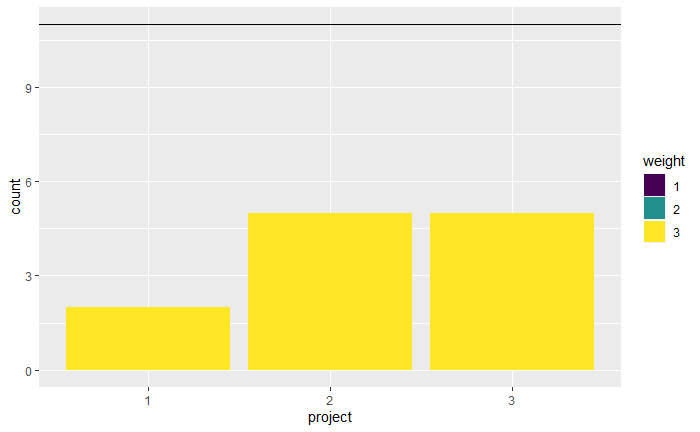

```r
plot_data <- matching %>%
  mutate(project = factor(j), weight = factor(weight, levels = c(1, 2, 3))) %>%
  group_by(project, weight) %>%
  summarise(count = n()) %>%
  tidyr::complete(weight, fill = list(count = 0))
ggplot(plot_data, aes(x = project, y = count, fill = weight)) +
  geom_bar(stat = "identity") +
  viridis::scale_fill_viridis(discrete = TRUE) +
  geom_hline(yintercept = 11)
```

Of course, with only 12 individuals and 3 project preferences among 4 gtoups, it was almost certain that we could accommodate them. The challenge would be with a significantly larger n-size. That can be simply done by changing the initial settings at the beginning of the r-script.